# Data science exam: part 1

## Introduction

In this first exam exercise you will work with world population data from https://data.worldbank.org/indicator/SP.POP.TOTL

You should make a fresh Quarto document and solve the exercises given below. You are allowed to work in groups of at most three people. Please make sure to include all group members as authors of the Quarto file.

Most of the exercises below show a preview of the result that you are supposed to obtain. Of course you should aim at recreating these results, but don’t give up if you don’t get exactly the same. Just explain what you did and argue why you think it is meaningful.

## Exercise 1

Read in the data in the file `world_population.csv` and select/deselect and rename columns so you end up with a tibble (`tbl`) named `wpop_full` with 266 rows and 65 columns with names as shown in the output below (the last column being `2022`). *Hint: Use `skip` in `read_csv` to avoid header lines not containing data or names of data.*

```
# A tibble: 266 × 65
   country  code  `1960` `1961` `1962` `1963` `1964` `1965` `1966` `1967` `1968`
   <chr>    <chr>  <dbl>  <dbl>  <dbl>  <dbl>  <dbl>  <dbl>  <dbl>  <dbl>  <dbl>
 1 Aruba    ABW   5.46e4 5.58e4 5.67e4 5.75e4 5.82e4 5.88e4 5.93e4 5.95e4 5.95e4
 2 Africa … AFE   1.31e8 1.34e8 1.38e8 1.42e8 1.46e8 1.50e8 1.54e8 1.58e8 1.63e8
 3 Afghani… AFG   8.62e6 8.79e6 8.97e6 9.16e6 9.36e6 9.57e6 9.78e6 1.00e7 1.02e7
 4 Africa … AFW   9.73e7 9.93e7 1.01e8 1.04e8 1.06e8 1.08e8 1.11e8 1.13e8 1.16e8
 5 Angola   AGO   5.36e6 5.44e6 5.52e6 5.60e6 5.67e6 5.74e6 5.79e6 5.83e6 5.87e6
 6 Albania  ALB   1.61e6 1.66e6 1.71e6 1.76e6 1.81e6 1.86e6 1.91e6 1.97e6 2.02e6
 7 Andorra  AND   9.44e3 1.02e4 1.10e4 1.18e4 1.27e4 1.36e4 1.45e4 1.57e4 1.71e4
 8 Arab Wo… ARB   9.34e7 9.58e7 9.83e7 1.01e8 1.04e8 1.06e8 1.09e8 1.12e8 1.16e8
 9 United … ARE   1.33e5 1.41e5 1.49e5 1.57e5 1.65e5 1.74e5 1.83e5 1.91e5 2.14e5
10 Argenti… ARG   2.03e7 2.07e7 2.10e7 2.14e7 2.17e7 2.21e7 2.24e7 2.28e7 2.31e7
# ℹ 256 more rows
# ℹ 54 more variables: `1969` <dbl>, `1970` <dbl>, `1971` <dbl>, `1972` <dbl>,
#   `1973` <dbl>, `1974` <dbl>, `1975` <dbl>, `1976` <dbl>, `1977` <dbl>,
#   `1978` <dbl>, `1979` <dbl>, `1980` <dbl>, `1981` <dbl>, `1982` <dbl>,
#   `1983` <dbl>, `1984` <dbl>, `1985` <dbl>, `1986` <dbl>, `1987` <dbl>,
#   `1988` <dbl>, `1989` <dbl>, `1990` <dbl>, `1991` <dbl>, `1992` <dbl>,
#   `1993` <dbl>, `1994` <dbl>, `1995` <dbl>, `1996` <dbl>, `1997` <dbl>, …
```

## Exercise 2

Use the package `rvest` to read in the list of country codes from the main table at https://en.wikipedia.org/wiki/ISO_3166-1 and select/deselect and rename columns so you end up with a tibble (`tbl`) named `iso_codes_all` with 249 rows and 3 columns with names as shown in the output below.

```r
iso_codes_all
```

```
# A tibble: 249 × 3
   name                iso3  independent
   <chr>               <chr> <chr>
 1 Afghanistan[b]      AFG   Yes
 2 Åland Islands       ALA   No
 3 Albania             ALB   Yes
 4 Algeria             DZA   Yes
 5 American Samoa      ASM   No
 6 Andorra             AND   Yes
 7 Angola              AGO   Yes
 8 Anguilla            AIA   No
 9 Antarctica          ATA   No
10 Antigua and Barbuda ATG   Yes
# ℹ 239 more rows
```

## Exercise 3

Use `filter()` to extract the independent countries from `iso_codes_all` and save the result as `iso_codes`.

```r
iso_codes
```

```
# A tibble: 194 × 3
   name                iso3  independent
   <chr>               <chr> <chr>
 1 Afghanistan[b]      AFG   Yes
 2 Albania             ALB   Yes
 3 Algeria             DZA   Yes
 4 Andorra             AND   Yes
 5 Angola              AGO   Yes
 6 Antigua and Barbuda ATG   Yes
 7 Argentina           ARG   Yes
 8 Armenia             ARM   Yes
 9 Australia           AUS   Yes
10 Austria             AUT   Yes
# ℹ 184 more rows
```

## Exercise 4

Use a suitable join (and/or filter) command to make a dataset `wpop` only containing those rows of `wpop_full` which have a matching ISO country code in `iso_codes`:

```r
wpop
```

```
# A tibble: 193 × 65
   country  code  `1960` `1961` `1962` `1963` `1964` `1965` `1966` `1967` `1968`
   <chr>    <chr>  <dbl>  <dbl>  <dbl>  <dbl>  <dbl>  <dbl>  <dbl>  <dbl>  <dbl>
 1 Afghani… AFG   8.62e6 8.79e6 8.97e6 9.16e6 9.36e6 9.57e6 9.78e6 1.00e7 1.02e7
 2 Angola   AGO   5.36e6 5.44e6 5.52e6 5.60e6 5.67e6 5.74e6 5.79e6 5.83e6 5.87e6
 3 Albania  ALB   1.61e6 1.66e6 1.71e6 1.76e6 1.81e6 1.86e6 1.91e6 1.97e6 2.02e6
 4 Andorra  AND   9.44e3 1.02e4 1.10e4 1.18e4 1.27e4 1.36e4 1.45e4 1.57e4 1.71e4
 5 United … ARE   1.33e5 1.41e5 1.49e5 1.57e5 1.65e5 1.74e5 1.83e5 1.91e5 2.14e5
 6 Argenti… ARG   2.03e7 2.07e7 2.10e7 2.14e7 2.17e7 2.21e7 2.24e7 2.28e7 2.31e7
 7 Armenia  ARM   1.90e6 1.97e6 2.04e6 2.11e6 2.17e6 2.23e6 2.30e6 2.36e6 2.42e6
 8 Antigua… ATG   5.53e4 5.62e4 5.70e4 5.78e4 5.87e4 5.96e4 6.06e4 6.16e4 6.27e4
 9 Austral… AUS   1.03e7 1.05e7 1.07e7 1.10e7 1.12e7 1.14e7 1.17e7 1.18e7 1.20e7
10 Austria  AUT   7.05e6 7.09e6 7.13e6 7.18e6 7.22e6 7.27e6 7.32e6 7.38e6 7.42e6
# ℹ 183 more rows
# ℹ 54 more variables: `1969` <dbl>, `1970` <dbl>, `1971` <dbl>, `1972` <dbl>,
#   `1973` <dbl>, `1974` <dbl>, `1975` <dbl>, `1976` <dbl>, `1977` <dbl>,
#   `1978` <dbl>, `1979` <dbl>, `1980` <dbl>, `1981` <dbl>, `1982` <dbl>,
#   `1983` <dbl>, `1984` <dbl>, `1985` <dbl>, `1986` <dbl>, `1987` <dbl>,
#   `1988` <dbl>, `1989` <dbl>, `1990` <dbl>, `1991` <dbl>, `1992` <dbl>,
#   `1993` <dbl>, `1994` <dbl>, `1995` <dbl>, `1996` <dbl>, `1997` <dbl>, …
```

## Exercise 5

Show the countries/areas which have the same ISO country code in both `wpop` and `iso_codes` but different (spellings of) country names.

```
# A tibble: 28 × 3
   name                              code  country
   <chr>                             <chr> <chr>
 1 Afghanistan[b]                    AFG   Afghanistan
 2 Bahamas                           BHS   Bahamas, The
 3 Bolivia, Plurinational State of   BOL   Bolivia
 4 China[b]                          CHN   China
 5 Côte d'Ivoire                     CIV   Cote d'Ivoire
 6 Congo, Democratic Republic of the COD   Congo, Dem. Rep.
 7 Congo                             COG   Congo, Rep.
 8 Cyprus[b]                         CYP   Cyprus
 9 Egypt                             EGY   Egypt, Arab Rep.
10 Micronesia, Federated States of   FSM   Micronesia, Fed. Sts.
# ℹ 18 more rows
```

## Exercise 6

Use the package `rvest` to read in the list of countries with corresponding continent codes from the main table at https://en.wikipedia.org/wiki/List_of_sovereign_states_and_dependent_territories_by_continent_(data_file) and select/deselect and rename columns so you end up with a tibble (`tbl`) named `continents` with 253 rows and 2 columns with names as shown in the output below.

**Important hint:** you need `convert = FALSE` in `html_table()` to avoid the text string `"NA"` (North America) to be interpreted as missing data (Not Available).

```r
continents
```

```
# A tibble: 253 × 2
   continent iso3
   <chr>     <chr>
 1 AS        AFG
 2 EU        ALB
 3 AN        ATA
 4 AF        DZA
 5 OC        ASM
 6 EU        AND
 7 AF        AGO
 8 NA        ATG
 9 AS        AZE
10 SA        ARG
# ℹ 243 more rows
```

## Exercise 7

Make a new dataset `wpop2` by extending `wpop` with the extra column `continent` from the `continents` data (possibly using `relocate()` to move the `continent` column to the left to see it more clearly).

```r
wpop2
```

```
# A tibble: 193 × 66
   continent country      code  `1960` `1961` `1962` `1963` `1964` `1965` `1966`
   <chr>     <chr>        <chr>  <dbl>  <dbl>  <dbl>  <dbl>  <dbl>  <dbl>  <dbl>
 1 AS        Afghanistan  AFG   8.62e6 8.79e6 8.97e6 9.16e6 9.36e6 9.57e6 9.78e6
 2 AF        Angola       AGO   5.36e6 5.44e6 5.52e6 5.60e6 5.67e6 5.74e6 5.79e6
 3 EU        Albania      ALB   1.61e6 1.66e6 1.71e6 1.76e6 1.81e6 1.86e6 1.91e6
 4 EU        Andorra      AND   9.44e3 1.02e4 1.10e4 1.18e4 1.27e4 1.36e4 1.45e4
 5 AS        United Arab… ARE   1.33e5 1.41e5 1.49e5 1.57e5 1.65e5 1.74e5 1.83e5
 6 SA        Argentina    ARG   2.03e7 2.07e7 2.10e7 2.14e7 2.17e7 2.21e7 2.24e7
 7 AS        Armenia      ARM   1.90e6 1.97e6 2.04e6 2.11e6 2.17e6 2.23e6 2.30e6
 8 NA        Antigua and… ATG   5.53e4 5.62e4 5.70e4 5.78e4 5.87e4 5.96e4 6.06e4
 9 OC        Australia    AUS   1.03e7 1.05e7 1.07e7 1.10e7 1.12e7 1.14e7 1.17e7
10 EU        Austria      AUT   7.05e6 7.09e6 7.13e6 7.18e6 7.22e6 7.27e6 7.32e6
# ℹ 183 more rows
# ℹ 56 more variables: `1967` <dbl>, `1968` <dbl>, `1969` <dbl>, `1970` <dbl>,
#   `1971` <dbl>, `1972` <dbl>, `1973` <dbl>, `1974` <dbl>, `1975` <dbl>,
#   `1976` <dbl>, `1977` <dbl>, `1978` <dbl>, `1979` <dbl>, `1980` <dbl>,
#   `1981` <dbl>, `1982` <dbl>, `1983` <dbl>, `1984` <dbl>, `1985` <dbl>,
#   `1986` <dbl>, `1987` <dbl>, `1988` <dbl>, `1989` <dbl>, `1990` <dbl>,
#   `1991` <dbl>, `1992` <dbl>, `1993` <dbl>, `1994` <dbl>, `1995` <dbl>, …
```

## Exercise 8

Use `pivot_longer()` to reshape `wpop2` into “long format” with columns as shown below (in particular make sure `year` is a numeric variable) and call the resulting tibble `pop_long`.

```r
pop_long
```

```
# A tibble: 12,159 × 5
   continent country     code   year      pop
   <chr>     <chr>       <chr> <dbl>    <dbl>
 1 AS        Afghanistan AFG    1960  8622466
 2 AS        Afghanistan AFG    1961  8790140
 3 AS        Afghanistan AFG    1962  8969047
 4 AS        Afghanistan AFG    1963  9157465
 5 AS        Afghanistan AFG    1964  9355514
 6 AS        Afghanistan AFG    1965  9565147
 7 AS        Afghanistan AFG    1966  9783147
 8 AS        Afghanistan AFG    1967 10010030
 9 AS        Afghanistan AFG    1968 10247780
10 AS        Afghanistan AFG    1969 10494489
# ℹ 12,149 more rows
```

## Exercise 9

Make a line plot showing the population over all the years in the data with one line per country with semi-transparent lines.

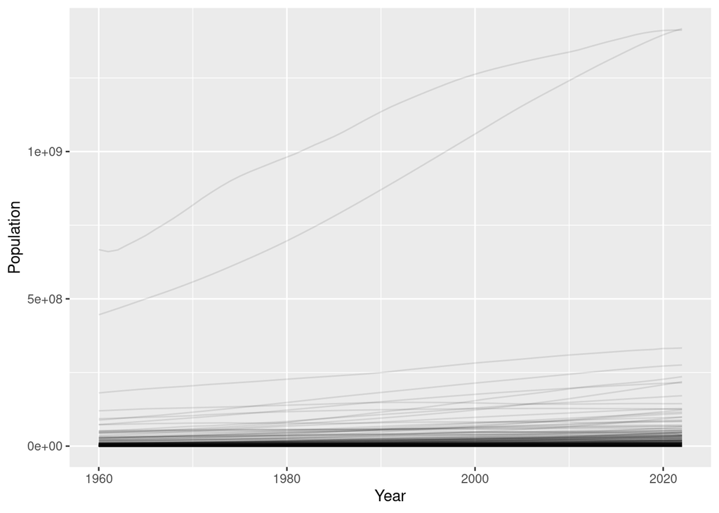

## Exercise 10

Use the code below to rescale each country’s population size to an population index which in 1 for every country in 1960. An index value of e.g. 2 would mean that the population size of that country has doubled since 1960.

```r
pop_index <- pop_long |>
  group_by(country,continent,code) |>
  mutate(pop_index = pop/pop[1])
```

## Exercise 11

Make a line plot showing the indexed population numbers over all the years in the data with one line per country with semi-transparent lines.

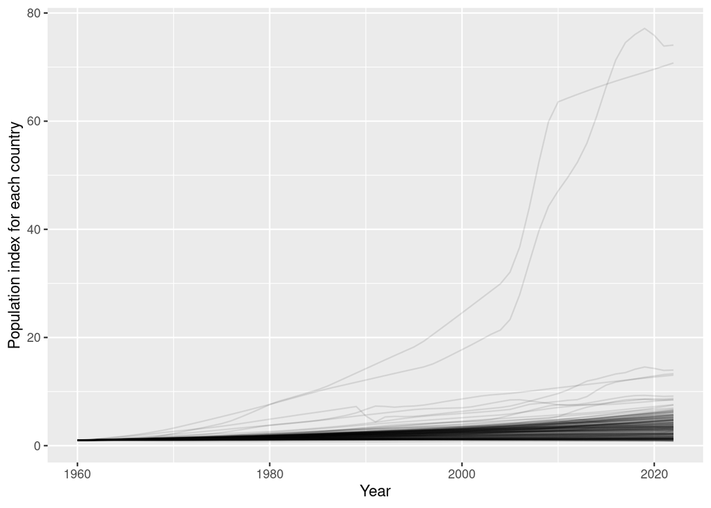

## Exercise 12

Identify the two countries with extreme population indices and make a new line plot showing the indexed population numbers over all the years in the data with one line per country with semi-transparent lines **without these two countries**.

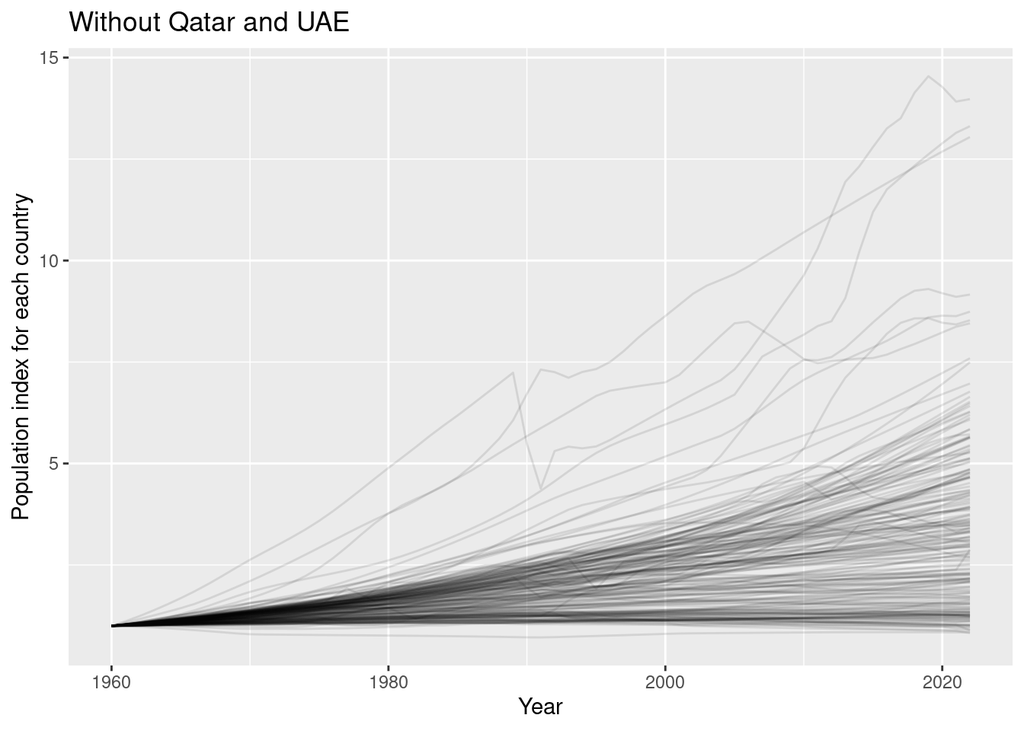

## Exercise 13

Run the following command and describe in a few words what the result `growth_long` is.

```r
growth_long <- pop_long |>
  group_by(country,continent,code) |>
  reframe(pop_start = pop[1:(length(pop)-1)],
          pop_end = pop[2:length(pop)],
          growth = 100*(pop_end-pop_start)/pop_start,
          end_year = year[2:length(year)])
```

## Exercise 14

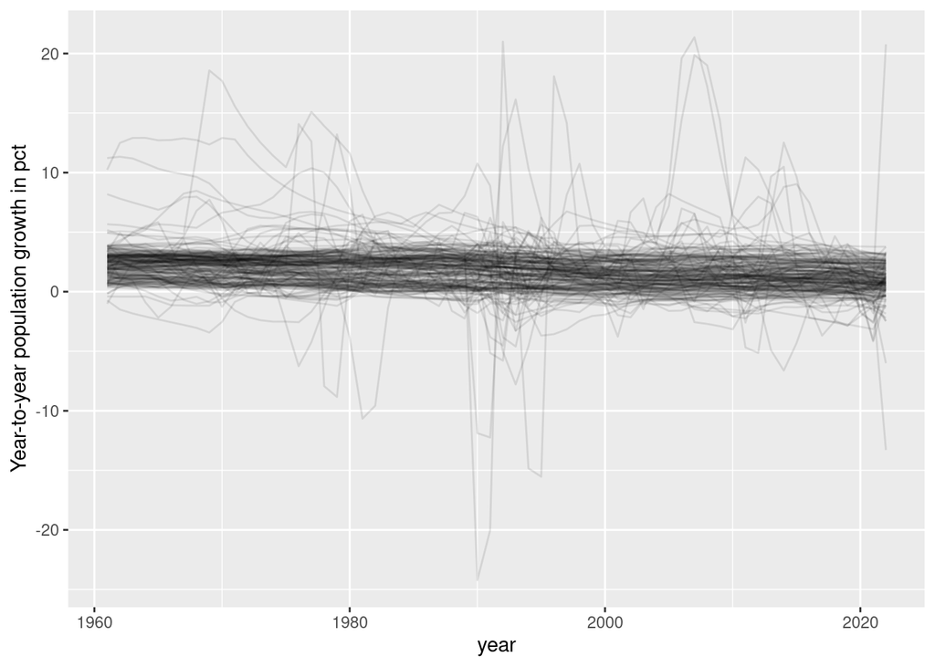

## Exercise 15

Make a similar graphic as above but with one panel/facet per continent.

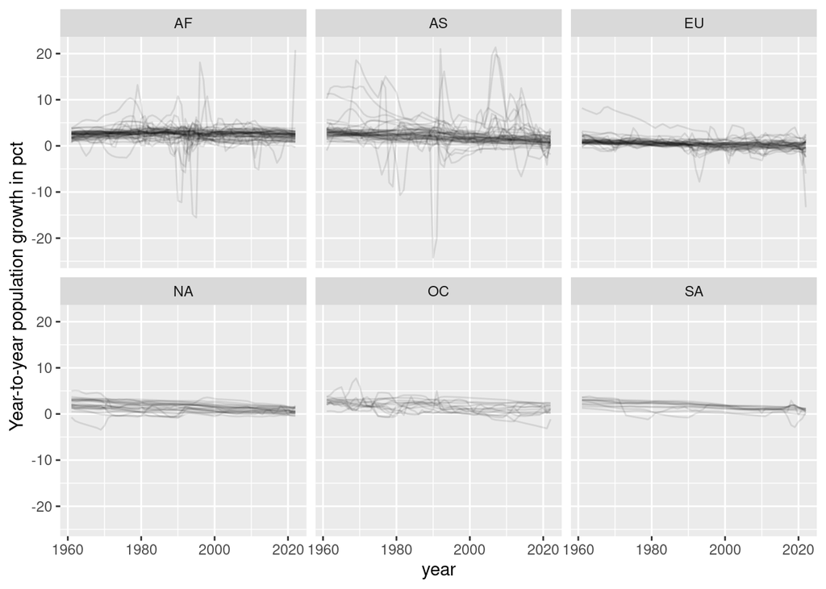

## Exercise 16

For each country find both the largest positive and the smallest (most negative) growth over the years in the data so you end up with a tibble (`tbl`) named `growth_range` with 193 rows and 3 columns with names as shown in the output below. *hint: `group_by()` and `summarise()` are your friends.*

```r
growth_range
```

```
# A tibble: 193 × 3
   country             max_growth min_growth
   <chr>                    <dbl>      <dbl>
 1 Afghanistan              16.1     -10.7
 2 Albania                   3.17     -1.21
 3 Algeria                   4.93      1.36
 4 Andorra                   8.47     -3.16
 5 Angola                    3.83      0.698
 6 Antigua and Barbuda       2.05     -0.577
 7 Argentina                 1.72      0.256
 8 Armenia                   3.54     -3.28
 9 Australia                 3.44      0.141
10 Austria                   1.13     -0.265
# ℹ 183 more rows
```

## Exercise 17

Find the 10 countries which have experienced the largest growth percentage of all at some point over the years in the data.

```r
top10
```

```
# A tibble: 10 × 3
   country              max_growth min_growth
   <chr>                     <dbl>      <dbl>
 1 Qatar                      21.4     -2.61
 2 Kuwait                     21.0    -24.2
 3 Seychelles                 20.8     -2.59
 4 United Arab Emirates       19.9      0.782
 5 Rwanda                     18.1    -15.5
 6 Afghanistan                16.1    -10.7
 7 Lebanon                    14.1     -8.83
 8 Somalia                    13.2     -4.52
 9 Jordan                     12.5      1.23
10 Oman                       11.3     -1.29
```

## Exercise 18

Find the 10 countries which have experienced the most negative growth percentage of all at some point over the years in the data.

```r
bottom10
```

```
# A tibble: 10 × 3
   country                max_growth min_growth
   <chr>                       <dbl>      <dbl>
 1 Kuwait                     21.0       -24.2
 2 Rwanda                     18.1       -15.5
 3 Ukraine                     1.40      -13.3
 4 Liberia                    10.7       -12.2
 5 Afghanistan                16.1       -10.7
 6 Lebanon                    14.1        -8.83
 7 Bosnia and Herzegovina      4.19       -7.78
 8 Syrian Arab Republic        6.54       -6.62
 9 Cambodia                    5.41       -6.25
10 Bulgaria                    0.963      -6.00
```

## Exercise 19

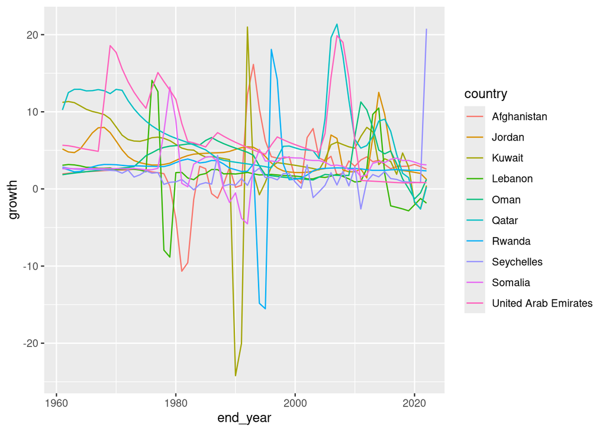

## Exercise 20

Use `pivot_wider()` to reshape `growth_long` to wide format with one column per year and call the result `growth`.

```r
growth
```

```
# A tibble: 193 × 65
   country      continent code  `1961` `1962` `1963` `1964` `1965` `1966` `1967`
   <chr>        <chr>     <chr>  <dbl>  <dbl>  <dbl>  <dbl>  <dbl>  <dbl>  <dbl>
 1 Afghanistan  AS        AFG    1.94   2.04   2.10   2.16   2.24   2.28   2.32
 2 Albania      EU        ALB    3.17   3.10   3.00   2.92   2.79   2.67   2.67
 3 Algeria      AF        DZA    1.79   1.55   1.62   1.75   1.66   1.87   2.25
 4 Andorra      EU        AND    8.19   7.81   7.49   7.19   6.88   7.25   8.24
 5 Angola       AF        AGO    1.57   1.47   1.42   1.31   1.12   0.880  0.699
 6 Antigua and… NA        ATG    1.63   1.36   1.35   1.53   1.67   1.63   1.65
 7 Argentina    SA        ARG    1.63   1.64   1.63   1.61   1.59   1.58   1.58
 8 Armenia      AS        ARM    3.54   3.44   3.28   3.08   2.90   2.75   2.64
 9 Australia    OC        AUS    2.01   2.47   1.94   1.98   1.98   2.31   1.27
10 Austria      EU        AUT    0.550  0.615  0.644  0.669  0.652  0.704  0.750
# ℹ 183 more rows
# ℹ 55 more variables: `1968` <dbl>, `1969` <dbl>, `1970` <dbl>, `1971` <dbl>,
#   `1972` <dbl>, `1973` <dbl>, `1974` <dbl>, `1975` <dbl>, `1976` <dbl>,
#   `1977` <dbl>, `1978` <dbl>, `1979` <dbl>, `1980` <dbl>, `1981` <dbl>,
#   `1982` <dbl>, `1983` <dbl>, `1984` <dbl>, `1985` <dbl>, `1986` <dbl>,
#   `1987` <dbl>, `1988` <dbl>, `1989` <dbl>, `1990` <dbl>, `1991` <dbl>,
#   `1992` <dbl>, `1993` <dbl>, `1994` <dbl>, `1995` <dbl>, `1996` <dbl>, …
```

## Exercise 21

Make a hierarchical clustering of the growth data in 9 groups. The following hints can be used to achieve this:

1. Remove non-numerical columns from data
2. Calculate distances
3. Use `hclust()` to run the clustering algorithm.
4. Use `cutree()` to make the cluster labels.
5. Use mutate to add the cluster label as a variable to `growth`

```r
growth_clust
```

```
# A tibble: 193 × 66
   clust country       continent code  `1961` `1962` `1963` `1964` `1965` `1966`
   <fct> <chr>         <chr>     <chr>  <dbl>  <dbl>  <dbl>  <dbl>  <dbl>  <dbl>
 1 1     Afghanistan   AS        AFG    1.94   2.04   2.10   2.16   2.24   2.28
 2 2     Albania       EU        ALB    3.17   3.10   3.00   2.92   2.79   2.67
 3 3     Algeria       AF        DZA    1.79   1.55   1.62   1.75   1.66   1.87
 4 4     Andorra       EU        AND    8.19   7.81   7.49   7.19   6.88   7.25
 5 3     Angola        AF        AGO    1.57   1.47   1.42   1.31   1.12   0.880
 6 2     Antigua and … NA        ATG    1.63   1.36   1.35   1.53   1.67   1.63
 7 2     Argentina     SA        ARG    1.63   1.64   1.63   1.61   1.59   1.58
 8 2     Armenia       AS        ARM    3.54   3.44   3.28   3.08   2.90   2.75
 9 2     Australia     OC        AUS    2.01   2.47   1.94   1.98   1.98   2.31
10 2     Austria       EU        AUT    0.550  0.615  0.644  0.669  0.652  0.704
# ℹ 183 more rows
# ℹ 56 more variables: `1967` <dbl>, `1968` <dbl>, `1969` <dbl>, `1970` <dbl>,
#   `1971` <dbl>, `1972` <dbl>, `1973` <dbl>, `1974` <dbl>, `1975` <dbl>,
#   `1976` <dbl>, `1977` <dbl>, `1978` <dbl>, `1979` <dbl>, `1980` <dbl>,
#   `1981` <dbl>, `1982` <dbl>, `1983` <dbl>, `1984` <dbl>, `1985` <dbl>,
#   `1986` <dbl>, `1987` <dbl>, `1988` <dbl>, `1989` <dbl>, `1990` <dbl>,
#   `1991` <dbl>, `1992` <dbl>, `1993` <dbl>, `1994` <dbl>, `1995` <dbl>, …
```

## Exercise 22

Use `group_split()` and `lapply()` similarly to below to extract the countries of each cluster and display them nicely with `pander::pander()`:

```r
growth_clust |>
  group_split(clust) |>
  lapply(function(x) x$country) |>
  pander::pander()
```

- Afghanistan

- *Albania*, *Antigua and Barbuda*, *Argentina*, *Armenia*, *Australia*, *Austria*, *Azerbaijan*, *Barbados*, *Belarus*, *Belgium*, *Bosnia and Herzegovina*, *Bulgaria*, *Cabo Verde*, *Canada*, *Chile*, *China*, *Croatia*, *Cuba*, *Cyprus*, *Czechia*, *Denmark*, *Dominica*, *El Salvador*, *Estonia*, *Fiji*, *Finland*, *France*, *Georgia*, *Germany*, *Greece*, *Grenada*, *Guyana*, *Hungary*, *Iceland*, *Ireland*, *Italy*, *Jamaica*, *Japan*, *Kazakhstan*, *Korea, Dem. People’s Rep.*, *Korea, Rep.*, *Latvia*, *Liechtenstein*, *Lithuania*, *Luxembourg*, *Malta*, *Mauritius*, *Moldova*, *Monaco*, *Montenegro*, *Myanmar*, *Nauru*, *Netherlands*, *New Zealand*, *North Macedonia*, *Norway*, *Palau*, *Poland*, *Portugal*, *Romania*, *Russian Federation*, *Samoa*, *San Marino*, *Serbia*, *Slovak Republic*, *Slovenia*, *Spain*, *Sri Lanka*, *St. Kitts and Nevis*, *St. Lucia*, *St. Vincent and the Grenadines*, *Suriname*, *Sweden*, *Switzerland*, *Thailand*, *Tonga*, *Trinidad and Tobago*, *Ukraine*, *United Kingdom*, *United States* and *Uruguay*

- *Algeria*, *Angola*, *Bahamas, The*, *Bahrain*, *Bangladesh*, *Belize*, *Benin*, *Bhutan*, *Bolivia*, *Botswana*, *Brazil*, *Brunei Darussalam*, *Burkina Faso*, *Burundi*, *Cambodia*, *Cameroon*, *Central African Republic*, *Chad*, *Colombia*, *Comoros*, *Congo, Dem. Rep.*, *Congo, Rep.*, *Costa Rica*, *Cote d’Ivoire*, *Dominican Republic*, *Ecuador*, *Egypt, Arab Rep.*, *Equatorial Guinea*, *Eritrea*, *Eswatini*, *Ethiopia*, *Gabon*, *Gambia, The*, *Ghana*, *Guatemala*, *Guinea*, *Guinea-Bissau*, *Haiti*, *Honduras*, *India*, *Indonesia*, *Iran, Islamic Rep.*, *Iraq*, *Israel*, *Kenya*, *Kiribati*, *Kyrgyz Republic*, *Lao PDR*, *Lesotho*, *Liberia*, *Libya*, *Madagascar*, *Malawi*, *Malaysia*, *Maldives*, *Mali*, *Mauritania*, *Mexico*, *Micronesia, Fed. Sts.*, *Mongolia*, *Morocco*, *Mozambique*, *Namibia*, *Nepal*, *Nicaragua*, *Niger*, *Nigeria*, *Pakistan*, *Panama*, *Papua New Guinea*, *Paraguay*, *Peru*, *Philippines*, *Sao Tome and Principe*, *Saudi Arabia*, *Senegal*, *Sierra Leone*, *Singapore*, *Solomon Islands*, *Somalia*, *South Africa*, *South Sudan*, *Sudan*, *Syrian Arab Republic*, *Tajikistan*, *Tanzania*, *Timor-Leste*, *Togo*, *Tunisia*, *Turkiye*, *Turkmenistan*, *Tuvalu*, *Uganda*, *Uzbekistan*, *Vanuatu*, *Venezuela, RB*, *Viet Nam*, *Yemen, Rep.*, *Zambia* and *Zimbabwe*

- *Andorra*, *Djibouti*, *Jordan*, *Marshall Islands* and *Oman*

- Kuwait

- Lebanon

- *Qatar* and *United Arab Emirates*

- Rwanda

- Seychelles

## Exercise 23

Use `pivot_longer()` to convert `growth_clust` to long format and plot growth as a function of time with a panel/facet for each cluster.

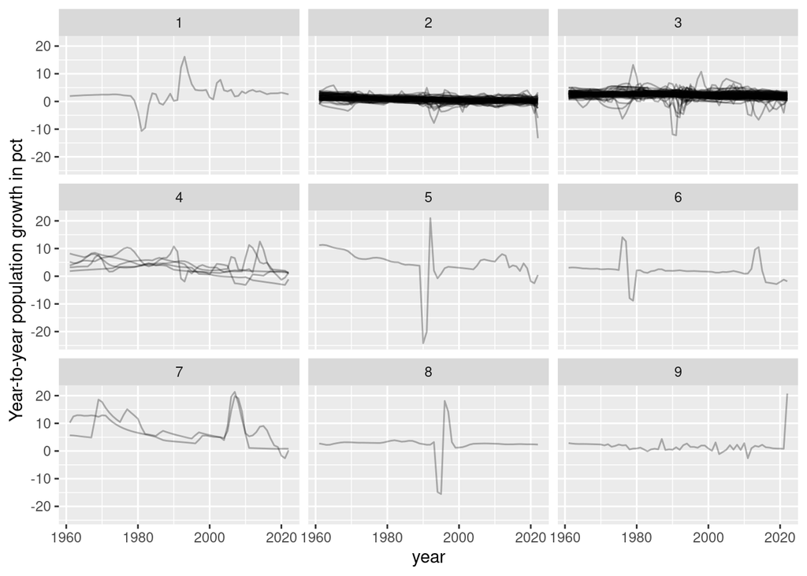

## Exercise

The code below can be used to calculate average growth rates over several years.

```r
agg_year <- 5
aggr_growth_long <- growth_long |>
  mutate(period=((end_year - min(end_year)) %/% agg_year) * agg_year + min(end_year)) |>
  group_by(period, code, country, continent) |> summarise(pop = mean(growth))
```

Use the clustering technique of the previous exercise to divide the data into different clusters. Experiment with several period lengths (aggregation years) and number of clusters and show results for at least one combination of `agg_year` and number of clusters. An example is given below.

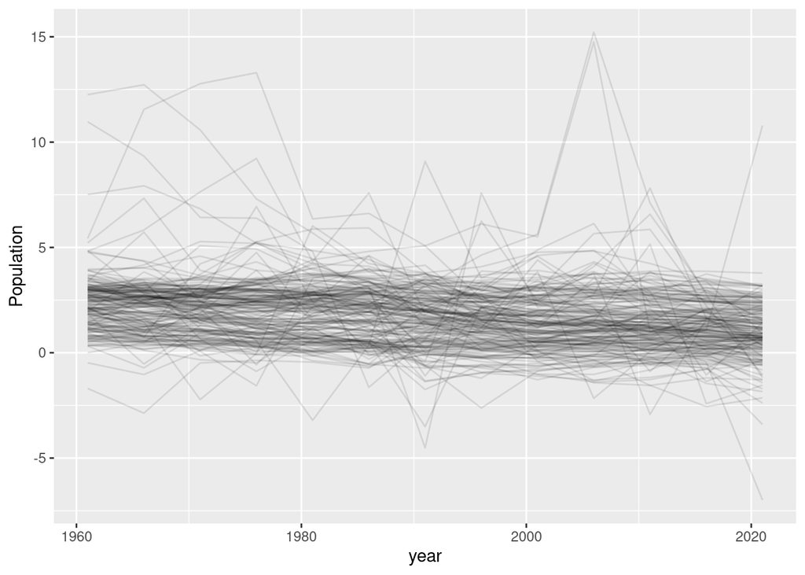

- Afghanistan

- *Angola*, *Burundi*, *Benin*, *Burkina Faso*, *Bangladesh*, *Bahrain*, *Bahamas, The*, *Belize*, *Bolivia*, *Brazil*, *Brunei Darussalam*, *Bhutan*, *Botswana*, *Central African Republic*, *Cote d’Ivoire*, *Cameroon*, *Congo, Dem. Rep.*, *Congo, Rep.*, *Colombia*, *Comoros*, *Cabo Verde*, *Costa Rica*, *Dominican Republic*, *Algeria*, *Ecuador*, *Egypt, Arab Rep.*, *Eritrea*, *Ethiopia*, *Micronesia, Fed. Sts.*, *Gabon*, *Ghana*, *Guinea*, *Gambia, The*, *Guinea-Bissau*, *Guatemala*, *Honduras*, *Haiti*, *Indonesia*, *India*, *Iran, Islamic Rep.*, *Iraq*, *Israel*, *Kenya*, *Kyrgyz Republic*, *Cambodia*, *Kiribati*, *Lao PDR*, *Lebanon*, *Liberia*, *Libya*, *Lesotho*, *Morocco*, *Madagascar*, *Maldives*, *Mexico*, *Mali*, *Mongolia*, *Mozambique*, *Mauritania*, *Malawi*, *Malaysia*, *Namibia*, *Niger*, *Nigeria*, *Nicaragua*, *Nepal*, *Nauru*, *Pakistan*, *Panama*, *Peru*, *Philippines*, *Palau*, *Papua New Guinea*, *Paraguay*, *Rwanda*, *Saudi Arabia*, *Sudan*, *Senegal*, *Singapore*, *Solomon Islands*, *Sierra Leone*, *Somalia*, *South Sudan*, *Sao Tome and Principe*, *Suriname*, *Eswatini*, *Syrian Arab Republic*, *Chad*, *Togo*, *Tajikistan*, *Turkmenistan*, *Timor-Leste*, *Tunisia*, *Turkiye*, *Tanzania*, *Uganda*, *Uzbekistan*, *Venezuela, RB*, *Viet Nam*, *Vanuatu*, *Yemen, Rep.*, *South Africa*, *Zambia* and *Zimbabwe*

- *Albania*, *Argentina*, *Armenia*, *Antigua and Barbuda*, *Australia*, *Austria*, *Azerbaijan*, *Belgium*, *Belarus*, *Canada*, *Switzerland*, *Chile*, *China*, *Cuba*, *Cyprus*, *Dominica*, *Denmark*, *Spain*, *Fiji*, *France*, *United Kingdom*, *Grenada*, *Guyana*, *Ireland*, *Iceland*, *Jamaica*, *Japan*, *Kazakhstan*, *St. Kitts and Nevis*, *Korea, Rep.*, *St. Lucia*, *Liechtenstein*, *Sri Lanka*, *Luxembourg*, *Monaco*, *North Macedonia*, *Malta*, *Myanmar*, *Mauritius*, *Netherlands*, *Norway*, *New Zealand*, *Poland*, *Korea, Dem. People’s Rep.*, *Russian Federation*, *El Salvador*, *San Marino*, *Slovak Republic*, *Slovenia*, *Sweden*, *Thailand*, *Tonga*, *Trinidad and Tobago*, *Tuvalu*, *Uruguay*, *United States*, *St. Vincent and the Grenadines* and *Samoa*

- *Andorra* and *Djibouti*

- *United Arab Emirates* and *Qatar*

- *Bulgaria*, *Bosnia and Herzegovina*, *Barbados*, *Czechia*, *Germany*, *Estonia*, *Finland*, *Georgia*, *Greece*, *Croatia*, *Hungary*, *Italy*, *Lithuania*, *Latvia*, *Moldova*, *Marshall Islands*, *Montenegro*, *Portugal*, *Romania*, *Serbia* and *Ukraine*

- *Equatorial Guinea*, *Jordan* and *Oman*

- Kuwait

- Seychelles

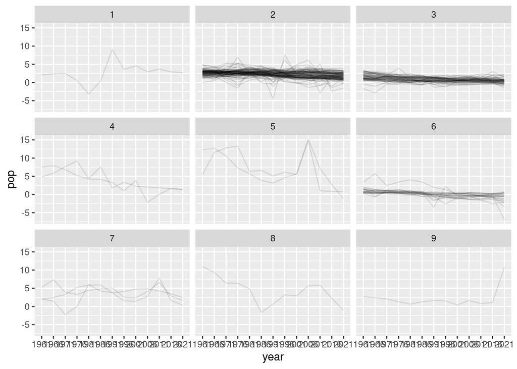